# Panel Data Estimators for Quantile Treatment Effects

Brantly Callaway

2026-11-24

## Overview

The `qte` package provides seven estimators of the quantile treatment effect on the treated (QTT) for settings where units are observed before and after treatment. All share the same `yname`/`gname`/`tname`/`idname` interface and support staggered treatment adoption. They differ in their identifying assumptions. Six are difference-in-differences-type assumptions, which restrict how untreated outcomes change over time; one, `lou_qtt()`, is a selection-on-observables assumption that conditions on the lagged outcome.

This vignette states each assumption and shows the minimal call. For the full applied workflow (aggregations, event studies, testing whether the effect is more than a location shift, covariates), see `vignette("staggered-adoption")`.

```r
library(qte)
library(ptetools)
library(ggplot2)
set.seed(42)
data(mpdta, package = "did")
```

We use `mpdta` throughout: a balanced panel of 500 US counties observed annually from 2003–2007, with `lemp` (log employment) as the outcome and `first.treat` as the cohort variable (year of first minimum wage increase; 0 = never treated).

The common call structure for all seven estimators is:

```r
estimator(
  yname  = "lemp",        # outcome
  gname  = "first.treat", # first treatment period (0 = never treated)
  tname  = "year",        # calendar time
  idname = "countyreal",  # unit id
  data   = mpdta,
  gt_type = "qtt",        # "qtt" (QTT curve) or "att"
  probs   = seq(0.1, 0.9, 0.1),
  biters  = 100
)
```

With `gt_type = "qtt"`, each estimator returns the QTT curve together with the ATT implied by the same assumption, both from the same bootstrap draws. Each plot below shows the overall QTT curve with a uniform confidence band and the overall ATT as a horizontal line.

All of these estimators except `cdf_did()` are built on quantiles or ranks and are designed for continuous outcomes. With a discrete outcome, or one with a large mass point (such as many zeros), quantile treatment effects are usually not point identified, and the estimators warn.

## Change in Changes — `cic()`

**Reference:** Athey and Imbens (2006)

**Identifying assumption:** The distributional time-change is the same for both groups: *Q*<sub>*Y*<sub>*t*</sub>(0)|*D* = 1</sub> (*F*<sub>*Y*<sub>*t* − 1</sub>(0)|*D* = 1</sub>(*y*)) = *Q*<sub>*Y*<sub>*t*</sub>(0)|*D* = 0</sub> (*F*<sub>*Y*<sub>*t* − 1</sub>(0)|*D* = 0</sub>(*y*)) for all *y*, along with a support condition: supp(*Y*<sub>*t* − 1</sub>(0)|*D* = 1) ⊆ supp(*Y*<sub>*t* − 1</sub>(0)|*D* = 0).

**Intuition:** The expression *Q*<sub>*Y*<sub>*t*</sub>(0)|*D* = *g*</sub>(*F*<sub>*Y*<sub>*t* − 1</sub>(0)|*D* = *g*</sub>(*y*)) takes a pre-period value *y*, finds its quantile rank in group *g*’s pre-period distribution, and returns the post-period value at that same rank within group *g*’s distribution. The assumption requires this operation to give the same result for both groups at every *y*. It can be thought of as a nonlinear version of parallel trends: where parallel trends requires the *mean* of *Y*(0) to shift equally across groups, CiC requires the *entire distributional time-change* to be the same. Athey and Imbens (2006) derive it from a model *Y*(0) = *h*(*U*, *t*) with *h* increasing in unobservables *U* whose distribution does not change over time within a group.

**Identification:** Under this assumption the counterfactual quantile function is *Q*<sub>*Y*<sub>*t*</sub>(0)|*D* = 1</sub>(*τ*) = *Q*<sub>*Y*<sub>*t*</sub>|*D* = 0</sub> (*F*<sub>*Y*<sub>*t* − 1</sub>|*D* = 0</sub> (*Q*<sub>*Y*<sub>*t* − 1</sub>|*D* = 1</sub>(*τ*))).

**Data:** Panel data or repeated cross sections (`panel = FALSE`).

```r
res_cic <- cic(
  yname  = "lemp", gname = "first.treat", tname = "year",
  idname = "countyreal", data = mpdta,
  gt_type = "qtt", probs = seq(0.1, 0.9, 0.1), biters = 100
)
autoplot(res_cic)
```

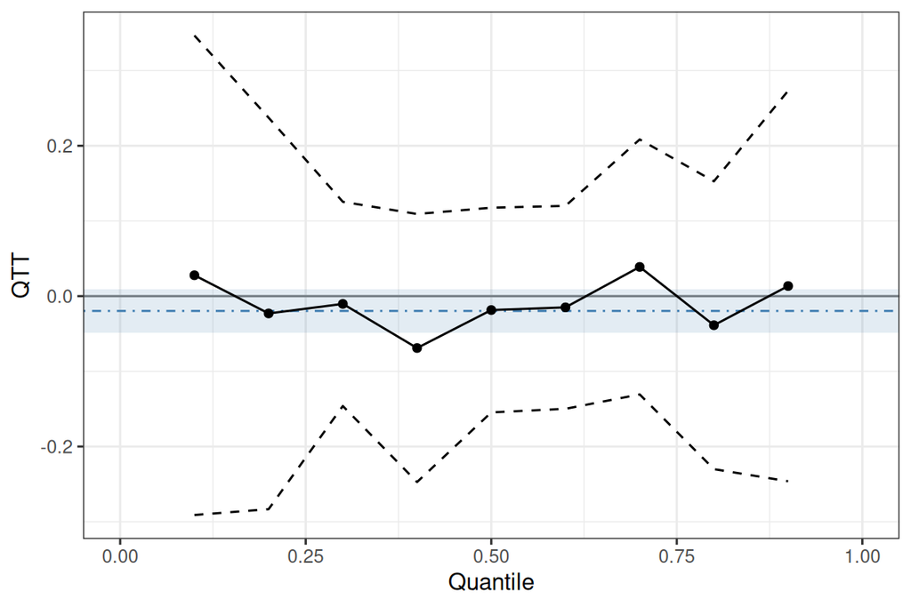

## Quantile Difference-in-Differences — `qdid()`

**References:** Athey and Imbens (2006); Meyer et al. (1995)

**Identifying assumption:** The change in quantiles over time is the same for both groups: *Q*<sub>*Y*<sub>*t*</sub>(0)|*D* = 1</sub>(*τ*) − *Q*<sub>*Y*<sub>*t* − 1</sub>(0)|*D* = 1</sub>(*τ*) = *Q*<sub>*Y*<sub>*t*</sub>(0)|*D* = 0</sub>(*τ*) − *Q*<sub>*Y*<sub>*t* − 1</sub>(0)|*D* = 0</sub>(*τ*) for all *τ* ∈ (0, 1).

**Intuition:** This requires parallel trends to hold at every quantile level *τ*, not just in the mean. It directly identifies the counterfactual: *Q*<sub>*Y*<sub>*t*</sub>(0)|*D* = 1</sub>(*τ*) = *Q*<sub>*Y*<sub>*t* − 1</sub>|*D* = 1</sub>(*τ*) + *Q*<sub>*Y*<sub>*t*</sub>|*D* = 0</sub>(*τ*) − *Q*<sub>*Y*<sub>*t* − 1</sub>|*D* = 0</sub>(*τ*).

**Data:** Panel data or repeated cross sections (`panel = FALSE`).

```r
res_qdid <- qdid(
  yname  = "lemp", gname = "first.treat", tname = "year",
  idname = "countyreal", data = mpdta,
  gt_type = "qtt", probs = seq(0.1, 0.9, 0.1), biters = 100
)
autoplot(res_qdid)
```

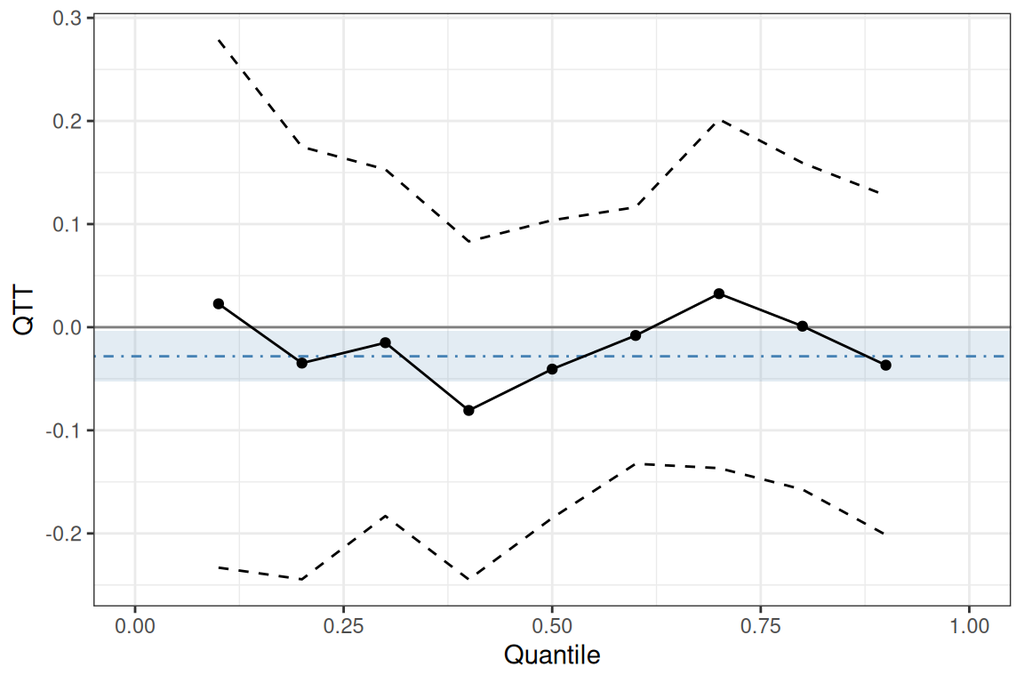

## Panel QTT — `panel_qtt()`

**Reference:** Callaway and Li (2019)

**Identifying assumptions:** The first assumption is *Δ**Y*<sub>*t*</sub>(0) ⟂ *D* — the distribution of the change in untreated potential outcomes is the same for both groups: *F*<sub>*Δ**Y*<sub>*t*</sub>(0)|*D* = 1</sub> = *F*<sub>*Δ**Y*<sub>*t*</sub>(0)|*D* = 0</sub>. This identifies the marginal distribution of *Δ**Y*<sub>*t*</sub>(0) for the treated group. As shown in Fan and Yu (2012), this is not sufficient on its own to identify the QTT. Identification is completed by a copula stability assumption: the copula linking *Δ**Y*<sub>*t*</sub>(0) to the lagged outcome *Y*<sub>*t* − 1</sub>(0) is stable over time within the treated group, *C*<sub>*Δ**Y*<sub>*t*</sub>(0), *Y*<sub>*t* − 1</sub>(0)|*D* = 1</sub> = *C*<sub>*Δ**Y*<sub>*t* − 1</sub>(0), *Y*<sub>*t* − 2</sub>(0)|*D* = 1</sub>.

**Intuition:** For treated units, *Y*<sub>*t* − 1</sub> and *Y*<sub>*t* − 2</sub> are observed pre-treatment, so the right-hand copula can be estimated directly from the data. Copula stability says this same dependence structure governs (*Δ**Y*<sub>*t*</sub>(0), *Y*<sub>*t* − 1</sub>(0)) in the post-period. Combined with the identified marginals, this pins down the conditional distribution of *Δ**Y*<sub>*t*</sub>(0) given *Y*<sub>*t* − 1</sub>(0) = *y* for treated units. Since *Y*<sub>*t*</sub>(0) = *Y*<sub>*t* − 1</sub> + *Δ**Y*<sub>*t*</sub>(0) and *Y*<sub>*t* − 1</sub> is observed, the QTT is identified.

**Data:** Panel data, with at least two pre-treatment periods per cohort. With staggered adoption, the default `pre_copula = "long"` uses a pre-treatment window as long as the post-treatment horizon, so longer event times need more pre-treatment periods; `pre_copula = "short"` always uses the two periods just before treatment.

```r
res_pqtt <- panel_qtt(
  yname  = "lemp", gname = "first.treat", tname = "year",
  idname = "countyreal", data = mpdta,
  gt_type = "qtt", probs = seq(0.1, 0.9, 0.1), biters = 100
)
autoplot(res_pqtt)
```

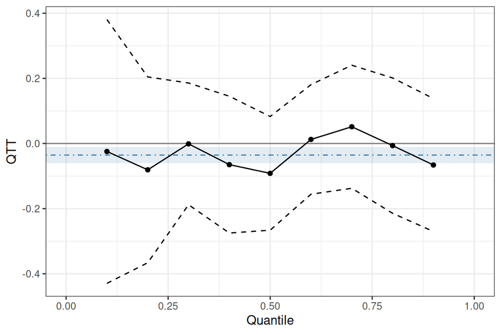

## Distributional DiD — `ddid()`

**Reference:** Callaway and Li (2019)

**Identifying assumptions:** The first is *Δ**Y*<sub>*t*</sub>(0) ⟂ *D* — the same as in `panel_qtt()`. The copula assumption differs: rather than stability over time, `ddid()` assumes the copula of (*Δ**Y*<sub>*t*</sub>(0), *Y*<sub>*t* − 1</sub>(0)) is the same for treated and untreated groups, *C*<sub>*Δ**Y*<sub>*t*</sub>(0), *Y*<sub>*t* − 1</sub>(0)|*D* = 1</sub> = *C*<sub>*Δ**Y*<sub>*t*</sub>(0), *Y*<sub>*t* − 1</sub>(0)|*D* = 0</sub>.

**Intuition:** For the untreated group, *Δ**Y*<sub>*t*</sub>(0) = *Δ**Y*<sub>*t*</sub> is observed, so the right-hand copula can be estimated directly. The assumption transfers it to the treated group. Combined with the identified marginals, this pins down the joint distribution of (*Δ**Y*<sub>*t*</sub>(0), *Y*<sub>*t* − 1</sub>(0)) for treated units and identifies the QTT — in exactly the same way as `panel_qtt()`. The key contrast is the source of the copula: `ddid()` borrows it from the untreated group at the same point in time, while `panel_qtt()` borrows it from the treated group’s own pre-treatment history.

**Data:** Panel data, with one pre-treatment period per cohort.

```r
res_ddid <- ddid(
  yname  = "lemp", gname = "first.treat", tname = "year",
  idname = "countyreal", data = mpdta,
  gt_type = "qtt", probs = seq(0.1, 0.9, 0.1), biters = 100
)
autoplot(res_ddid)
```

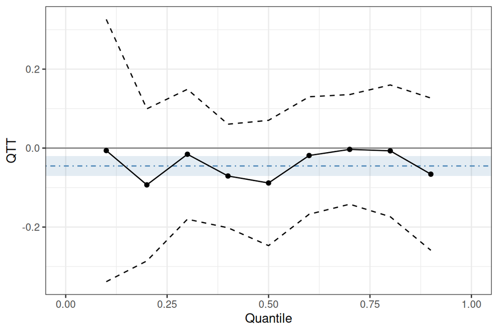

## Mean Difference-in-Differences — `mdid()`

**Reference:** Thuysbaert (2007)

**Identifying assumption:** The counterfactual quantile for the treated group in the post-period is the pre-period quantile shifted by the mean change in outcomes for the untreated group: *Q*<sub>*Y*<sub>*t*</sub>(0)|*D* = 1</sub>(*τ*) = *Q*<sub>*Y*<sub>*t* − 1</sub>|*D* = 1</sub>(*τ*) + *E*[*Y*<sub>*t*</sub>|*D* = 0] − *E*[*Y*<sub>*t* − 1</sub>|*D* = 0].

**Intuition:** The assumption says the shape of the treated group’s outcome distribution is unchanged in the counterfactual — the entire distribution simply shifts by the amount the untreated group’s mean changed. This implies mean parallel trends, so the ATT is the usual DiD estimate, but it is stronger: it additionally requires that only the location of the untreated distribution changes over time, not its shape.

**Data:** Panel data or repeated cross sections (`panel = FALSE`).

```r
res_mdid <- mdid(
  yname  = "lemp", gname = "first.treat", tname = "year",
  idname = "countyreal", data = mpdta,
  gt_type = "qtt", probs = seq(0.1, 0.9, 0.1), biters = 100
)
autoplot(res_mdid)
```

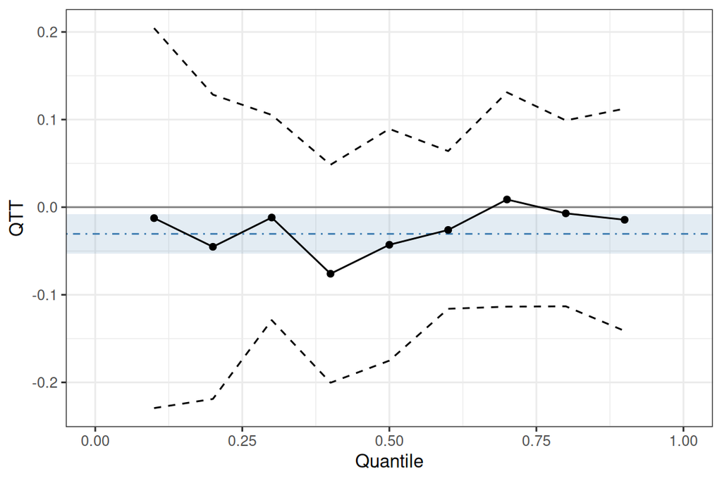

## Parallel Trends in Distribution Functions — `cdf_did()`

**Reference:** Roth and Sant’Anna (2023)

**Identifying assumption:** The change over time in the distribution function of untreated potential outcomes is the same for both groups, at every value *y*: *F*<sub>*Y*<sub>*t*</sub>(0)|*D* = 1</sub>(*y*) − *F*<sub>*Y*<sub>*t* − 1</sub>(0)|*D* = 1</sub>(*y*) = *F*<sub>*Y*<sub>*t*</sub>(0)|*D* = 0</sub>(*y*) − *F*<sub>*Y*<sub>*t* − 1</sub>(0)|*D* = 0</sub>(*y*) for all *y*.

**Intuition:** This is parallel trends for every indicator 1{*Y* ≤ *y*} instead of for *Y* itself. Roth and Sant’Anna (2023) show that it is essentially the condition under which parallel trends holds for every strictly monotone transformation of the outcome (logs, levels, …), so it is the natural assumption when the choice of units is arbitrary. It implies mean parallel trends, so the ATT is the usual DiD estimate. The counterfactual distribution is *F*<sub>*Y*<sub>*t*</sub>(0)|*D* = 1</sub>(*y*) = *F*<sub>*Y*<sub>*t* − 1</sub>|*D* = 1</sub>(*y*) + *F*<sub>*Y*<sub>*t*</sub>|*D* = 0</sub>(*y*) − *F*<sub>*Y*<sub>*t* − 1</sub>|*D* = 0</sub>(*y*). In finite samples the right-hand side need not be a valid distribution function; `cdf_did()` rearranges it into one (Chernozhukov et al. 2010) and reports how much that changed it.

Unlike the rank- and quantile-based estimators above, this assumption identifies the counterfactual distribution for discrete outcomes too. With covariates, `est_method = c("aipw", "ipw", "reg")` gives doubly robust, inverse-probability-weighted and outcome-regression versions of the conditional assumption (Sant’Anna and Zhao 2020), applied at each threshold *y*.

**Data:** Panel data or repeated cross sections (`panel = FALSE`).

```r
res_cdf <- cdf_did(
  yname  = "lemp", gname = "first.treat", tname = "year",
  idname = "countyreal", data = mpdta,
  gt_type = "qtt", probs = seq(0.1, 0.9, 0.1), biters = 100
)
autoplot(res_cdf)
```

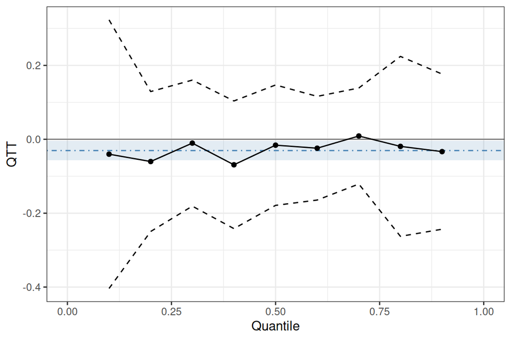

## Lagged-Outcome Unconfoundedness — `lou_qtt()`

**Identifying assumption:** Conditional on the pre-treatment outcome (and any covariates *X*), untreated potential outcomes are independent of treatment: *Y*<sub>*t*</sub>(0) ⟂ *D* ∣ *Y*<sub>*t* − 1</sub>, *X*.

**Intuition:** Treatment is as good as randomly assigned among units with the same pre-treatment outcome. This is not a parallel trends assumption: selection may depend on the level of the lagged outcome but, given it, not on unobserved unit-specific heterogeneity. DiD-type assumptions instead allow selection on time-invariant unobservables. The two are not nested, and when they disagree it is informative to report both. The counterfactual distribution is estimated by inverse probability weighting, outcome (quantile) regression, or a doubly robust combination (`est_method = c("aipw", "ipw", "reg")`).

**Data:** Panel data. With `lagged_outcome_cov = FALSE` the lagged outcome is dropped from the conditioning set, leaving unconfoundedness given *X*, which also works with repeated cross sections.

```r
res_lou <- lou_qtt(
  yname  = "lemp", gname = "first.treat", tname = "year",
  idname = "countyreal", data = mpdta,
  gt_type = "qtt", probs = seq(0.1, 0.9, 0.1), biters = 100
)
autoplot(res_lou)
```

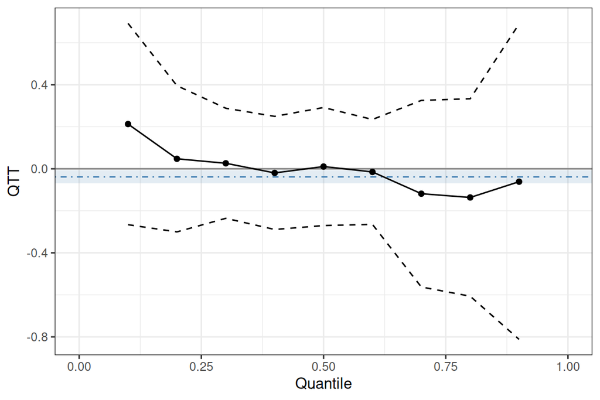

## Summary

| Function | Identifying assumption | Repeated cross sections | Notes |
| --- | --- | --- | --- |
| `cic()` | Same distributional time-change for both groups (changes-in-changes) | Yes | Needs a support condition; continuous outcomes |
| `qdid()` | Parallel trends in every quantile | Yes | Continuous outcomes |
| `panel_qtt()` | Parallel trends in the distribution of changes + copula stable over time | No | Needs ≥ 2 pre-treatment periods |
| `ddid()` | Parallel trends in the distribution of changes + same copula for both groups | No |  |
| `mdid()` | Treated distribution shifts by the comparison group’s mean change | Yes | Implies mean parallel trends, and is stronger |
| `cdf_did()` | Parallel trends in distribution functions | Yes | Also identified for discrete outcomes |
| `lou_qtt()` | Unconfoundedness given the lagged outcome | With `lagged_outcome_cov = FALSE` | Not a parallel trends assumption |

All seven take covariates through `xformula`. All return a `pte_qtt` object for `gt_type = "qtt"`, or a `pte_emp_boot` object for `gt_type = "att"`, with `summary()` and `autoplot()` methods. See `vignette("staggered-adoption")` for the full applied workflow.

## References

Athey, Susan, and Guido Imbens. 2006. “Identification and Inference in Nonlinear Difference-in-Differences Models.” *Econometrica* 74 (2): 431–97.

Callaway, Brantly, and Tong Li. 2019. “Quantile Treatment Effects in Difference in Differences Models with Panel Data.” *Quantitative Economics* 10 (4): 1579–618.

Chernozhukov, Victor, Ivan Fernandez-Val, and Alfred Galichon. 2010. “Quantile and Probability Curves Without Crossing.” *Econometrica* 78 (3): 1093–125.

Fan, Yanqin, and Zhengfei Yu. 2012. “Partial Identification of Distributional and Quantile Treatment Effects in Difference-in-Differences Models.” *Economics Letters* 115 (3): 511–15.

Meyer, Bruce, Kip Viscusi, and David Durbin. 1995. “Workers’ Compensation and Injury Duration: Evidence from a Natural Experiment.” *American Economic Review*, 322–40.

Roth, Jonathan, and Pedro HC Sant’Anna. 2023. “When Is Parallel Trends Sensitive to Functional Form?” *Econometrica* 91 (2): 737–47.

Sant’Anna, Pedro HC, and Jun Zhao. 2020. “Doubly Robust Difference-in-Differences Estimators.” *Journal of Econometrics* 219 (1): 101–22.

Thuysbaert, Bram. 2007. “Distributional Comparisons in Difference in Differences Models.” Unpublished manuscript.